# 326.212 Homework 1

y = ..prop..의 경우 geom_bar의 default stat인 stat_count()의 prop에 저장된 값을 y값으로 가져와서 사용하겠다는 것이므로,

```r
plt <- ggplot(data = diamonds) +
  geom_bar(mapping = aes(x = cut))
plt_b <- ggplot_build(plt)
knitr::kable(plt_b$data[[1]])
```

| y | count | prop | x | PANEL | group | ymin | ymax | xmin | xmax | colour | fill | size | linetype | alpha |
| --- | --- | --- | --- | --- | --- | --- | --- | --- | --- | --- | --- | --- | --- | --- |
| 1610 | 1610 | 1 | 1 | 1 | 1 | 0 | 1610 | 0.55 | 1.45 | NA | grey35 | 0.5 | 1 | NA |
| 4906 | 4906 | 1 | 2 | 1 | 2 | 0 | 4906 | 1.55 | 2.45 | NA | grey35 | 0.5 | 1 | NA |
| 12082 | 12082 | 1 | 3 | 1 | 3 | 0 | 12082 | 2.55 | 3.45 | NA | grey35 | 0.5 | 1 | NA |
| 13791 | 13791 | 1 | 4 | 1 | 4 | 0 | 13791 | 3.55 | 4.45 | NA | grey35 | 0.5 | 1 | NA |
| 21551 | 21551 | 1 | 5 | 1 | 5 | 0 | 21551 | 4.55 | 5.45 | NA | grey35 | 0.5 | 1 | NA |

에서는 prop과 group column을 보면, 모두 그룹이 제각각이고 그에따라 prop의 값도 1로 계산되었음을 알 수 있고,

```r
plt <- ggplot(data = diamonds) +
  geom_bar(mapping = aes(x = cut, group = 1))
plt_b <- ggplot_build(plt)
knitr::kable(plt_b$data[[1]])
```

| y | count | prop | x | group | PANEL | ymin | ymax | xmin | xmax | colour | fill | size | linetype | alpha |
| --- | --- | --- | --- | --- | --- | --- | --- | --- | --- | --- | --- | --- | --- | --- |
| 1610 | 1610 | 0.0298480 | 1 | 1 | 1 | 0 | 1610 | 0.55 | 1.45 | NA | grey35 | 0.5 | 1 | NA |
| 4906 | 4906 | 0.0909529 | 2 | 1 | 1 | 0 | 4906 | 1.55 | 2.45 | NA | grey35 | 0.5 | 1 | NA |
| 12082 | 12082 | 0.2239896 | 3 | 1 | 1 | 0 | 12082 | 2.55 | 3.45 | NA | grey35 | 0.5 | 1 | NA |
| 13791 | 13791 | 0.2556730 | 4 | 1 | 1 | 0 | 13791 | 3.55 | 4.45 | NA | grey35 | 0.5 | 1 | NA |
| 21551 | 21551 | 0.3995365 | 5 | 1 | 1 | 0 | 21551 | 4.55 | 5.45 | NA | grey35 | 0.5 | 1 | NA |

에서는 prop과 group column을 보면, 모두 그룹이 1로 지정되어있고 그에따라 prop의 값도 제각각 계산되었음을 확인할 수 있다.

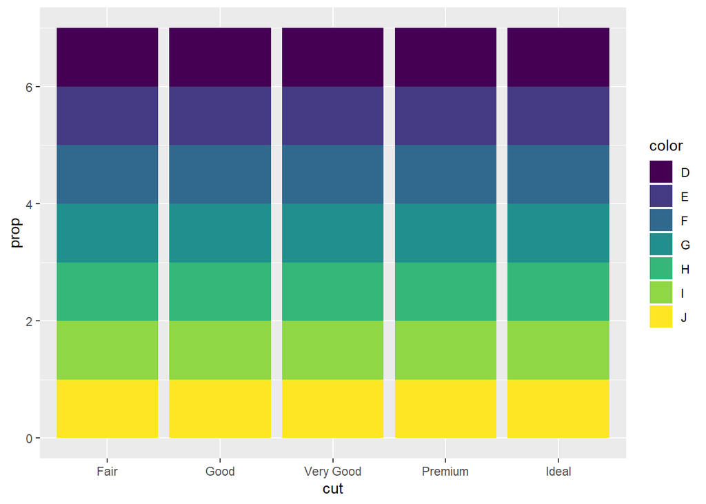

```r
ggplot(data = diamonds) +
  geom_bar(mapping = aes(x = cut, fill = color, y = ..prop..))
```

위 코드의 경우에는 문제가 더 심각한데, x = cut에다 fill = color로 지정한 경우에는 그루핑이 cut 뿐만 아니라 color에 따라서도 그루핑이 되기때문에 (cut 종류 * color 종류)개의 그룹이 생기고, 그 그룹 각각에서의 prop은 모두 1이기때문에 prop의 높이가 7인 그래프 5개가 나오게 된다.

```r
plt <- ggplot(data = diamonds) +
  geom_bar(mapping = aes(x = cut, fill = color, y = ..prop..))
plt_b <- ggplot_build(plt)
knitr::kable(plt_b$data[[1]])
```

| fill | y | count | prop | x | PANEL | group | ymin | ymax | xmin | xmax | colour | size | linetype | alpha |
| --- | --- | --- | --- | --- | --- | --- | --- | --- | --- | --- | --- | --- | --- | --- |
| #FDE725FF | 1 | 119 | 1 | 1 | 1 | 7 | 0 | 1 | 0.55 | 1.45 | NA | 0.5 | 1 | NA |
| #8FD744FF | 2 | 175 | 1 | 1 | 1 | 6 | 1 | 2 | 0.55 | 1.45 | NA | 0.5 | 1 | NA |
| #35B779FF | 3 | 303 | 1 | 1 | 1 | 5 | 2 | 3 | 0.55 | 1.45 | NA | 0.5 | 1 | NA |
| #21908CFF | 4 | 314 | 1 | 1 | 1 | 4 | 3 | 4 | 0.55 | 1.45 | NA | 0.5 | 1 | NA |
| #31688EFF | 5 | 312 | 1 | 1 | 1 | 3 | 4 | 5 | 0.55 | 1.45 | NA | 0.5 | 1 | NA |
| #443A83FF | 6 | 224 | 1 | 1 | 1 | 2 | 5 | 6 | 0.55 | 1.45 | NA | 0.5 | 1 | NA |
| #440154FF | 7 | 163 | 1 | 1 | 1 | 1 | 6 | 7 | 0.55 | 1.45 | NA | 0.5 | 1 | NA |
| #FDE725FF | 1 | 307 | 1 | 2 | 1 | 14 | 0 | 1 | 1.55 | 2.45 | NA | 0.5 | 1 | NA |
| #8FD744FF | 2 | 522 | 1 | 2 | 1 | 13 | 1 | 2 | 1.55 | 2.45 | NA | 0.5 | 1 | NA |
| #35B779FF | 3 | 702 | 1 | 2 | 1 | 12 | 2 | 3 | 1.55 | 2.45 | NA | 0.5 | 1 | NA |
| #21908CFF | 4 | 871 | 1 | 2 | 1 | 11 | 3 | 4 | 1.55 | 2.45 | NA | 0.5 | 1 | NA |
| #31688EFF | 5 | 909 | 1 | 2 | 1 | 10 | 4 | 5 | 1.55 | 2.45 | NA | 0.5 | 1 | NA |
| #443A83FF | 6 | 933 | 1 | 2 | 1 | 9 | 5 | 6 | 1.55 | 2.45 | NA | 0.5 | 1 | NA |
| #440154FF | 7 | 662 | 1 | 2 | 1 | 8 | 6 | 7 | 1.55 | 2.45 | NA | 0.5 | 1 | NA |
| #FDE725FF | 1 | 678 | 1 | 3 | 1 | 21 | 0 | 1 | 2.55 | 3.45 | NA | 0.5 | 1 | NA |
| #8FD744FF | 2 | 1204 | 1 | 3 | 1 | 20 | 1 | 2 | 2.55 | 3.45 | NA | 0.5 | 1 | NA |
| #35B779FF | 3 | 1824 | 1 | 3 | 1 | 19 | 2 | 3 | 2.55 | 3.45 | NA | 0.5 | 1 | NA |
| #21908CFF | 4 | 2299 | 1 | 3 | 1 | 18 | 3 | 4 | 2.55 | 3.45 | NA | 0.5 | 1 | NA |
| #31688EFF | 5 | 2164 | 1 | 3 | 1 | 17 | 4 | 5 | 2.55 | 3.45 | NA | 0.5 | 1 | NA |
| #443A83FF | 6 | 2400 | 1 | 3 | 1 | 16 | 5 | 6 | 2.55 | 3.45 | NA | 0.5 | 1 | NA |
| #440154FF | 7 | 1513 | 1 | 3 | 1 | 15 | 6 | 7 | 2.55 | 3.45 | NA | 0.5 | 1 | NA |
| #FDE725FF | 1 | 808 | 1 | 4 | 1 | 28 | 0 | 1 | 3.55 | 4.45 | NA | 0.5 | 1 | NA |
| #8FD744FF | 2 | 1428 | 1 | 4 | 1 | 27 | 1 | 2 | 3.55 | 4.45 | NA | 0.5 | 1 | NA |
| #35B779FF | 3 | 2360 | 1 | 4 | 1 | 26 | 2 | 3 | 3.55 | 4.45 | NA | 0.5 | 1 | NA |
| #21908CFF | 4 | 2924 | 1 | 4 | 1 | 25 | 3 | 4 | 3.55 | 4.45 | NA | 0.5 | 1 | NA |
| #31688EFF | 5 | 2331 | 1 | 4 | 1 | 24 | 4 | 5 | 3.55 | 4.45 | NA | 0.5 | 1 | NA |
| #443A83FF | 6 | 2337 | 1 | 4 | 1 | 23 | 5 | 6 | 3.55 | 4.45 | NA | 0.5 | 1 | NA |
| #440154FF | 7 | 1603 | 1 | 4 | 1 | 22 | 6 | 7 | 3.55 | 4.45 | NA | 0.5 | 1 | NA |
| #FDE725FF | 1 | 896 | 1 | 5 | 1 | 35 | 0 | 1 | 4.55 | 5.45 | NA | 0.5 | 1 | NA |
| #8FD744FF | 2 | 2093 | 1 | 5 | 1 | 34 | 1 | 2 | 4.55 | 5.45 | NA | 0.5 | 1 | NA |
| #35B779FF | 3 | 3115 | 1 | 5 | 1 | 33 | 2 | 3 | 4.55 | 5.45 | NA | 0.5 | 1 | NA |
| #21908CFF | 4 | 4884 | 1 | 5 | 1 | 32 | 3 | 4 | 4.55 | 5.45 | NA | 0.5 | 1 | NA |
| #31688EFF | 5 | 3826 | 1 | 5 | 1 | 31 | 4 | 5 | 4.55 | 5.45 | NA | 0.5 | 1 | NA |
| #443A83FF | 6 | 3903 | 1 | 5 | 1 | 30 | 5 | 6 | 4.55 | 5.45 | NA | 0.5 | 1 | NA |
| #440154FF | 7 | 2834 | 1 | 5 | 1 | 29 | 6 | 7 | 4.55 | 5.45 | NA | 0.5 | 1 | NA |

group의 종류가 무지막지하게 많다.